# Midpoint Deliverable Report

Xinyu Wang, Shaosui Hong, Crystal Wen, Yufei Zhang

5/24/2020

## The purpose/importance of the project

- We are interested in the domain of **Health**, and subdomain of **Nutrition**, because we are in a situation where we are required to stay home. During the coronavirus epidemic, maintaining a healthy and strong body became the priority and it should always be. Therefore, adopting a healthy diet is more necessary than ever. Moreover, as restaurants are only taking to-go orders, more and more people have decided to cook for themselves, acknowledging the nutrients for each food item would be helpful.
- Due to our current situation with Covid-19, we are interested in how nutrition impacts us. In this project, we will be analyzing the nutritional value of different food products. Furthermore, we will also analyze how nutrition may impact a countries recovery rate based on the dataset of covid-19 condition and information.

## Summary Information

The Covid-19 diet study included a total of 33 different features. The highest death proportion was 0.07%, and the country that had this death rate was Belgium. On the other hand, the lowest death proportion was 0%, and the countries that had this death rate were Cambodia, Central African Republic, Dominica, Fiji, Grenada, Lao People’s Democratic Republic, Madagascar, Mongolia, Mozambique, Namibia, Nepal, Rwanda, Saint Kitts and Nevis, Saint Lucia, Saint Vincent and the Grenadines, Timor-Leste, Uganda, Vietnam. Furthermore, this dataset included the proportion of the population that was undernourished. The highest proportion was 59.6% for the countries of Central African Republic. What’s more, the undernourished rate of countries like Australia, Austria, Azerbaijan, Belarus, Belgium, Bosnia and Herzegovina, Brazil, Canada, Croatia, Cuba, Czechia, Denmark, Finland, France, Germany, Greece, Hungary, Iceland, Ireland, Israel, Italy, Japan, Kazakhstan, Korea, South, Latvia, Lithuania, Luxembourg, Malaysia, Malta, Montenegro, Netherlands, New Zealand, Norway, Poland, Portugal, Romania, Russian Federation, Slovenia, Spain, Sweden, Switzerland, Turkey, United Kingdom, USA, Uruguay are under 2.5%.

## Aggregate Table

### Explaining why the particular grouping calculation was performed

- In this aggregate table, we want to find out how the diet structure correlate to the recovery from covid-19. Therefore, we explored the proportion of protein and vitamine take in and the obesity rate for those recovered people from different region. This can provide people information about how they should adjust their diet to prevent or recover from covid-19.

| Region | Recovery | Protein | Obesity | Fruit_and_Veges |
| --- | --- | --- | --- | --- |
| SouthernAsia | 0.01% | 9.95% | 7.76% | 44.68% |
| Caribbean | 0.01% | 11.31% | 23.79% | 48.88% |
| EasternAfrica | 0.01% | 5.66% | 6.94% | 49.64% |
| NorthernAfrica | 0% | 9.21% | 23.6% | 47.09% |
| South-easternAsia | 0% | 7.49% | 6.95% | 47.71% |
| WesternAfrica | 0% | 5.97% | 7.87% | 47.68% |
| MiddleAfrica | 0% | 6.04% | 8.54% | 50.66% |
| Melanesia | 0% | 7.22% | 24.67% | 46.68% |
| Micronesia | NaN% | 8.81% | 45.6% | 46.99% |
| Polynesia | NaN% | 12.35% | 45.5% | 44.81% |

## Charts

### Chart 1 (Undernourished Rate by Country)

#### Description of what the chart attempts to answer/understand

- This chart shows the undernourished rate of each country on a map to demostrate the distribution of it.

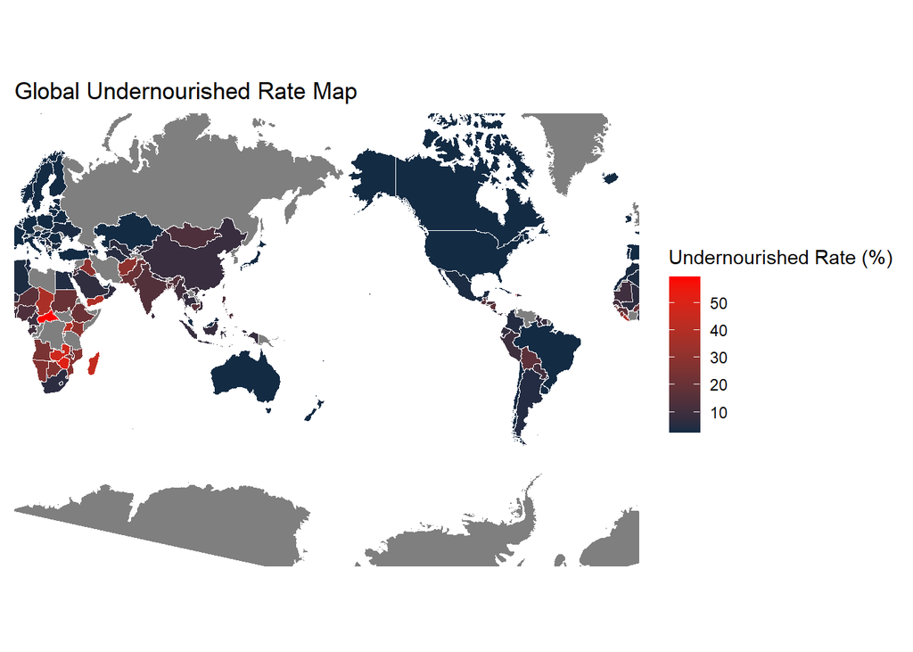

#### Description of what the chart attempts to answer/understand

- This chart shows the confirmed case of covid-19 of each region(continent). From the above chart one, we find that the undernourished rate varies from Continent to Continent. In this chart, we are trying to demonstrate the proportion of confirmed case in differnt Continents. So, a pie chart should be the most effective way.

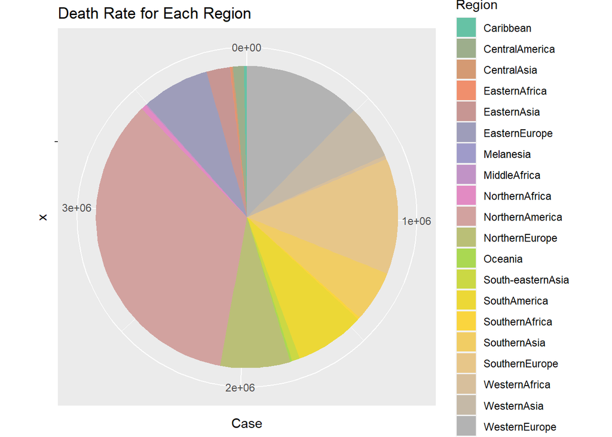

#### Interprets information from the chart, honing in on important information

- Here in the chart we can easily find the largest proportion is North America which takes up almost one third of the total cases.

### Chart 3 (% of Obesity Vs % of COVID Confirmed Cases)

#### Description of what the chart attempts to answer/understand

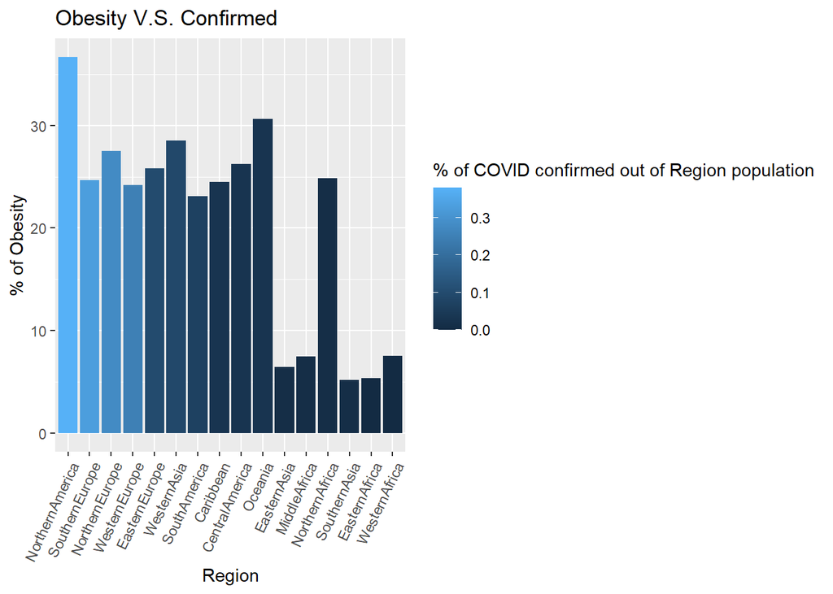

#### Interprets information from the chart, honing in on important information

- I found out that NorthernAmerica has both the highest % of obesity and % of COVID confirmed cases. However, the region that has the second highest % of COVID confirmed cases is SouthernEurope, but SouthernEurope does **not** have the second highest % of Obesity, which shows that there is **no obvious correlation** between obesity and the chance of COVID-19 infection. But the chart also indicates that the Regions that have the lower % of COVID confirmed cases also have a very low % of obesity, such as EasternAsia, MiddleAfrica, SouthernAsia, EasternAfrica, and WesternAfrica.